# Regressão Linear Múltipla

## Análise do Modelo 2

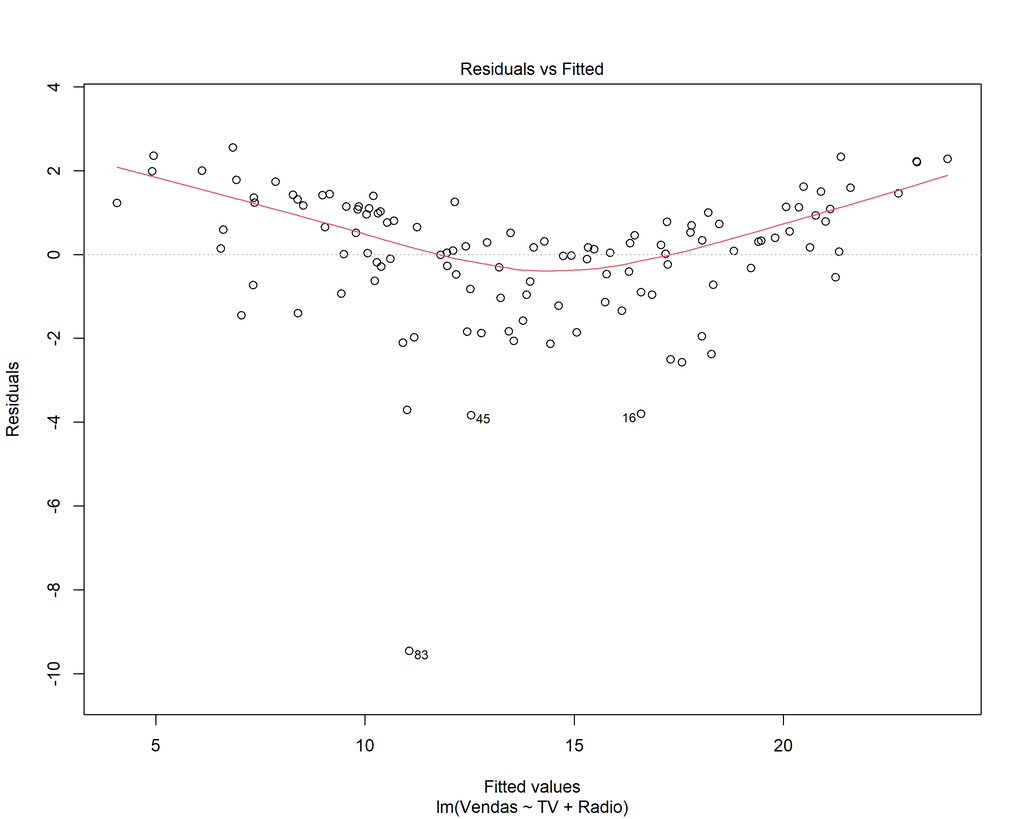

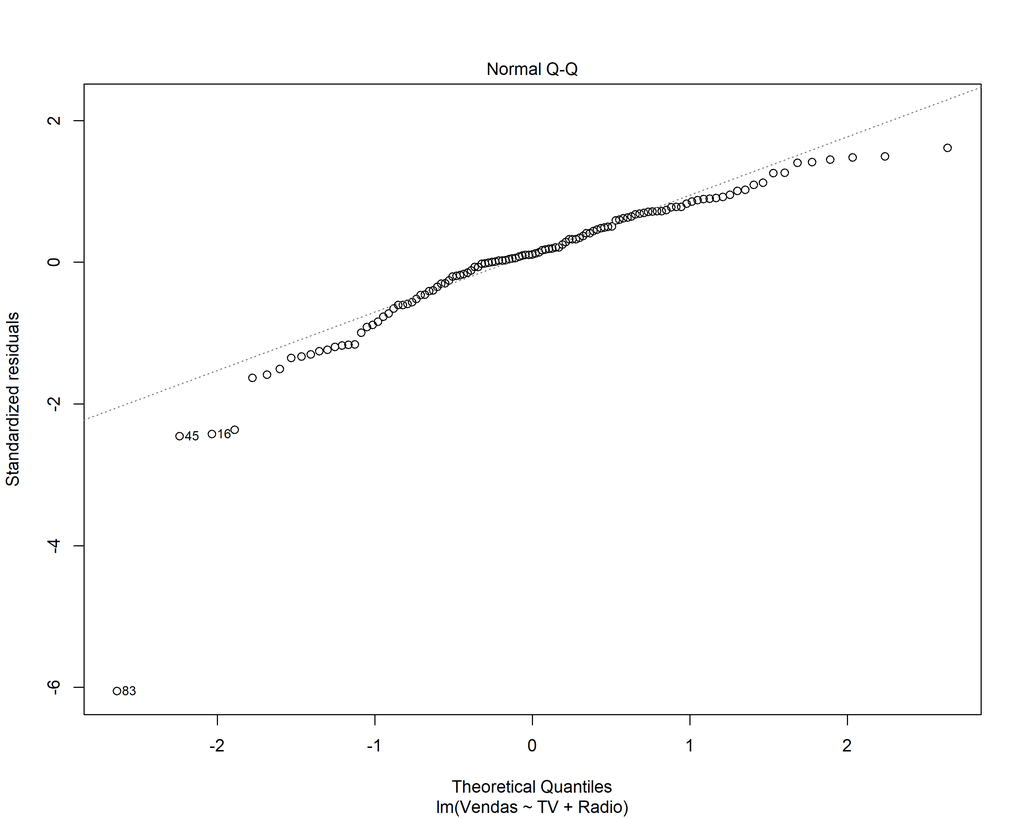

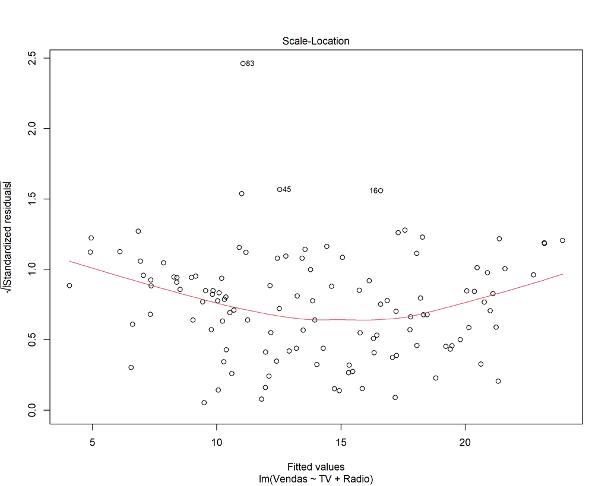

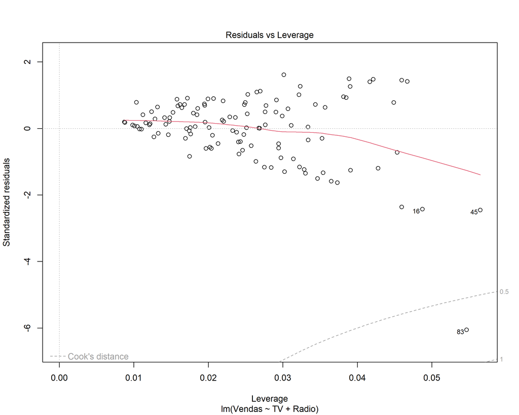

```r
plot(mod5)
```

## Análise do Modelo 3

Para o gráfico de resíduos versus valores ajustados, podemos usar um teste chamado teste de Tukey de não aditividade (Tukey, 1949), ele é obtido adicionando os quadrados dos valores ajustados ao modelo e reajustando. O valor p para o teste de Tukey é obtido comparando a estatística de teste para a distribuição padrão-normal. O teste confirma a visível impressão de curvatura no gráfico residual, reforçando ainda mais a conclusão que o modelo não é adequado.

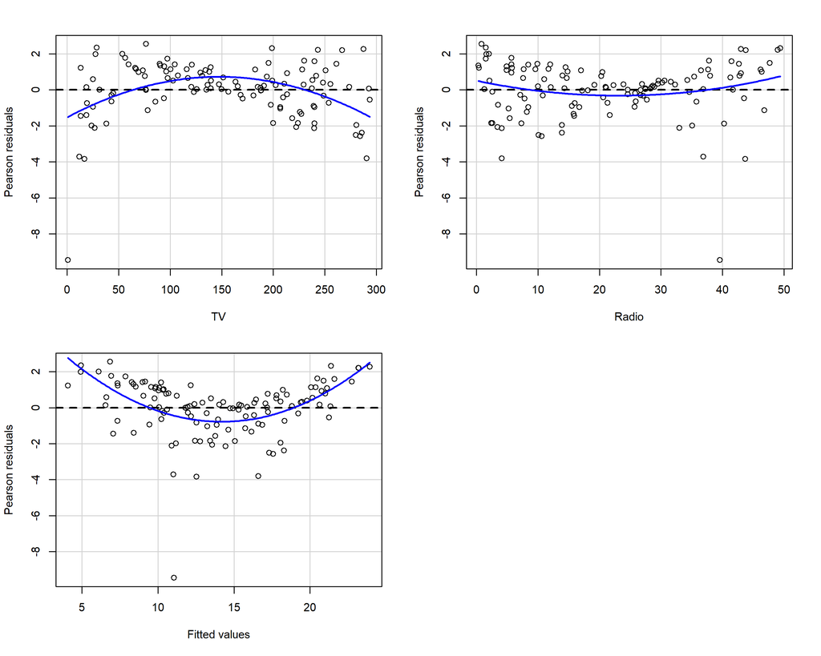

```
##            Test stat Pr(>|Test stat|)
## TV           -4.8383        4.102e-06 ***
## Radio         1.9290           0.0562 .
## Tukey test    6.4114        1.442e-10 ***
## ---
## Signif. codes:  0 '***' 0.001 '**' 0.01 '*' 0.05 '.' 0.1 ' ' 1
```

```r
library(car)
residualPlots(mod5)
```

## Análise do Modelo com car

```r
library(car)
vif(mod5)
```

```
##       TV    Radio
## 1.014454 1.014454
```

## Tentando corrigir o problema

```r
summary(p1 <- powerTransform(Vendas ~ TV + Radio, data=conj_treino))
```

```
## bcPower Transformation to Normality
##    Est Power Rounded Pwr Wald Lwr Bnd Wald Upr Bnd
## Y1    0.9937           1       0.8018       1.1856
##
## Likelihood ratio test that transformation parameter is equal to 0
##  (log transformation)
##                           LRT df       pval
## LR test, lambda = (0) 111.042  1 < 2.22e-16
##
## Likelihood ratio test that no transformation is needed
##                               LRT df    pval
## LR test, lambda = (1) 0.004149754  1 0.94864
```

```r
summary(p2 <- powerTransform(cbind(TV, Radio) ~1 , data=conj_treino))
```

```
## bcPower Transformations to Multinormality
##       Est Power Rounded Pwr Wald Lwr Bnd Wald Upr Bnd
## TV       0.7692         1.0       0.5311       1.0073
## Radio    0.5349         0.5       0.3429       0.7269
##
## Likelihood ratio test that transformation parameters are equal to 0
##  (all log transformations)
##                             LRT df       pval
## LR test, lambda = (0 0) 102.457  2 < 2.22e-16
##
## Likelihood ratio test that no transformations are needed
##                            LRT df       pval
## LR test, lambda = (1 1) 22.189  2 1.5196e-05
```

```r
mod6 <- lm( log(Vendas) ~ TV + Radio, data = conj_treino)
summary(mod6)
```

```
##
## Call:
## lm(formula = log(Vendas) ~ TV + Radio, data = conj_treino)
##
## Residuals:
##      Min       1Q   Median       3Q      Max
## -1.77994 -0.05255  0.04368  0.10055  0.17353
##
## Coefficients:
##             Estimate Std. Error t value Pr(>|t|)
## (Intercept) 1.791156   0.043994  40.713  < 2e-16 ***
## TV          0.003492   0.000218  16.022  < 2e-16 ***
## Radio       0.011524   0.001280   9.006 5.04e-15 ***
## ---
## Signif. codes:  0 '***' 0.001 '**' 0.01 '*' 0.05 '.' 0.1 ' ' 1
##
## Residual standard error: 0.1975 on 116 degrees of freedom
## Multiple R-squared:  0.765,  Adjusted R-squared:  0.761
## F-statistic: 188.8 on 2 and 116 DF,  p-value: < 2.2e-16
```

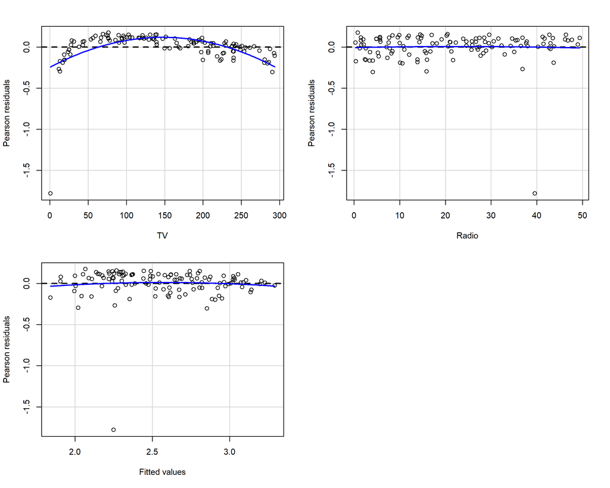

```
##            Test stat Pr(>|Test stat|)
## TV           -6.8943        3.092e-10 ***
## Radio        -0.2563           0.7982
## Tukey test   -0.5761           0.5646
## ---
## Signif. codes:  0 '***' 0.001 '**' 0.01 '*' 0.05 '.' 0.1 ' ' 1
```

```r
residualPlots(mod6)
```

## Dado que parece outlier e é um valor influente

A função OutlierTest () no pacote do car localiza o maior resíduo studentizado em valor absoluto e calcula o teste t com correção de Bonferroni. O testes de Outlier utiliza uma distribuição t para testar se o maior valor do residuo studentizado do modelo é estatisticamente diferente das outras observações. Um valor p significativo indica um outlier extremo que merece um exame mais aprofundado.

```r
outlierTest(mod6)
```

```
##     rstudent unadjusted p-value Bonferroni p
## 83 -18.13798         1.5879e-35   1.8896e-33
```

```r
conj_treino[83,]
```

```
## # A tibble: 1 × 4
##      TV Radio Jornal Vendas
##   <dbl> <dbl>  <dbl>  <dbl>
## 1   0.7  39.6    8.7    1.6
```